# Внешний курс. Блок 1: Безопасность в сети

Основы информационной безопасности

Петрова А.А.

Российский университет дружбы народов, Москва, Россия

16 мая 2025

# Информация

## Докладчик

- Петрова Алевтина Александровна
- НКАбд-04-23
- Российский университет дружбы народов

## Задание

Выполнение контрольных заданий первого блока внешнего курса “Основы Кибербезопасности”

## Вопрос 2.1.1

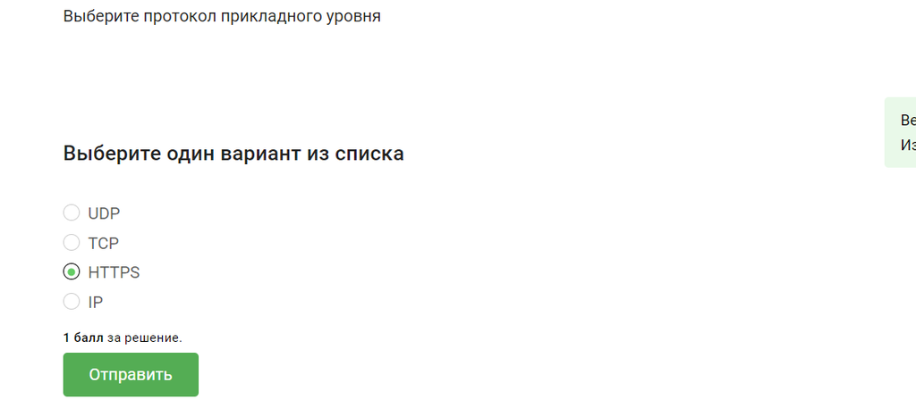

## Вопрос 2.1.2

Ранее было упомянуто, что протокол TCP - transmission control protocol - работает на транспортном уровне

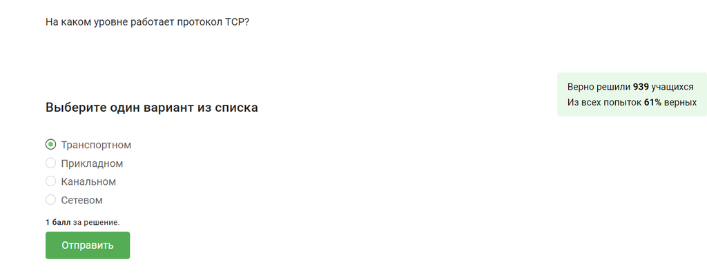

## Вопрос 2.1.3

В адресе типа IPv4 не может быть чисел больше 255, поэтому первые два варианта не подходят

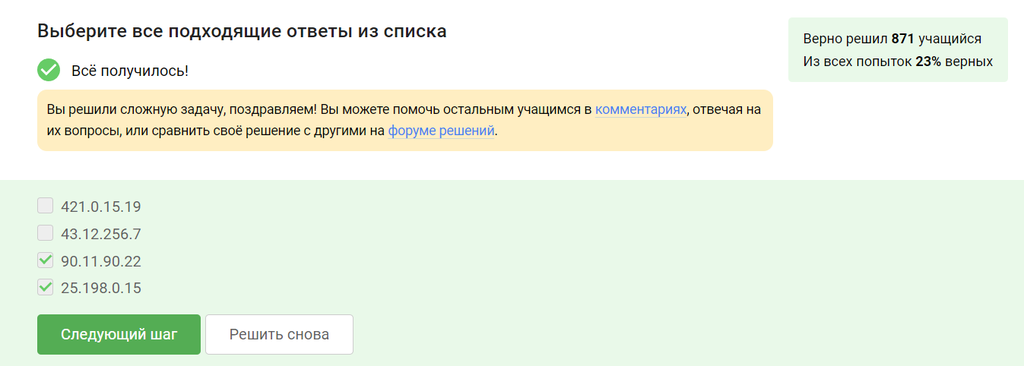

## Вопрос 2.1.4

DNS-сервер, Domain name server — приложение, предназначенное для ответов на DNS-запросы по соответствующему протоколу Обязательное условие – Сопоставление сервером доменных имен доменного имени с IP-адресом называется разрешением имени и адреса

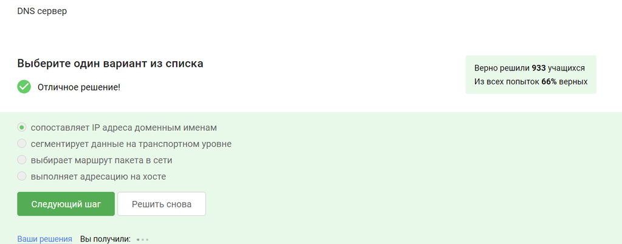

## Вопрос 2.1.5

Распределение протоколов в модели TCP/IP:

- Прикладной уровень (Application Layer): HTTP, RTSP, FTP, DNS.
- Транспортный уровень (Transport Layer): TCP, UDP, SCTP, DCCP.
- Сетевой (Межсетевой) уровень (Network Layer): IP.
- Уровень сетевого доступа (Канальный) (Link Layer): Ethernet, IEEE 802.11, WLAN, SLIP, Token Ring, ATM и MPLS.

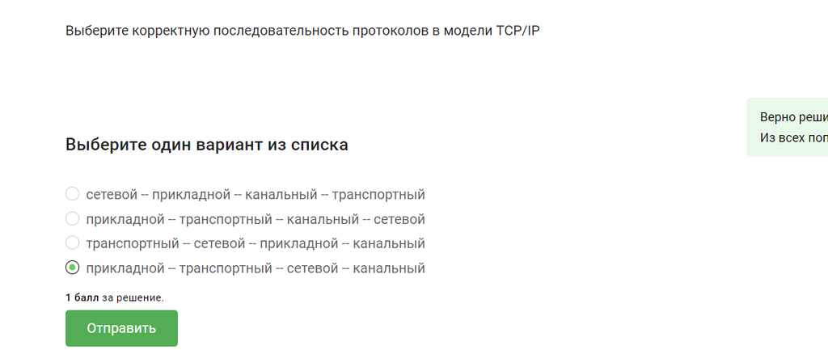

## Вопрос 2.1.6

Протокол http передает не зашифрованные данные, а протокол https уже будет передавать зашифрованные данные

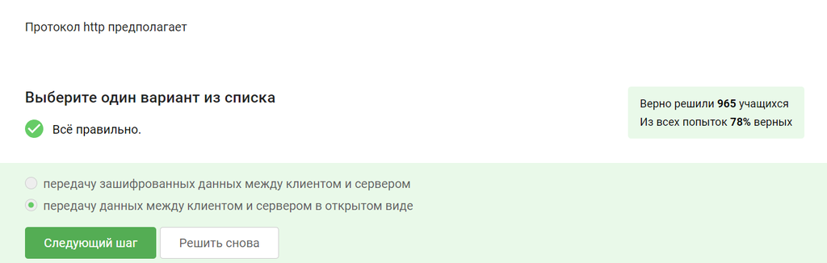

## Вопрос 2.1.7

https передает зашифрованные данные, одна из фаз - передача данных, другая должна быть рукопожатием

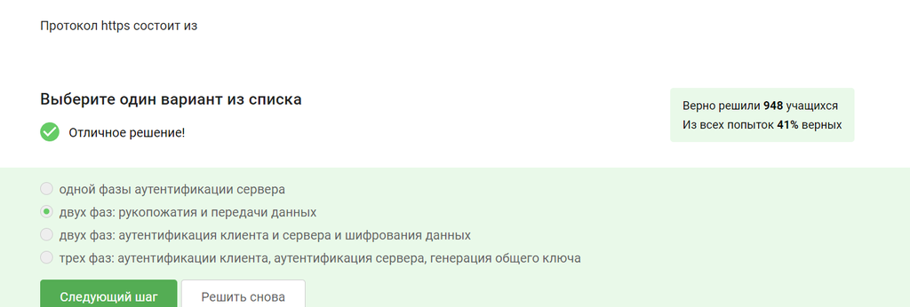

## Вопрос 2.1.8

TLS определяется и клиентом, и сервером, чтобы было возможно подключиться

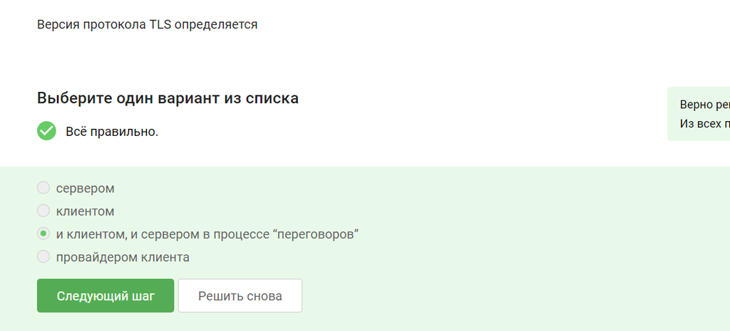

## Вопрос 2.1.9

Ответ на изображении, остальные варианты в протоколе предусмотрены

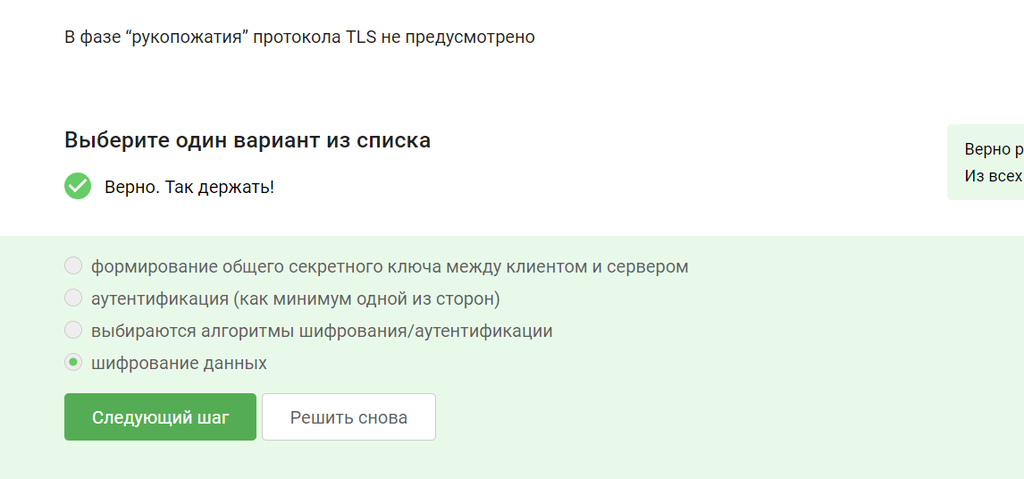

## Вопрос 2.2.1

Куки точно не хранят пароли и IP-адреса, а id ceccии и идентификатор хранят

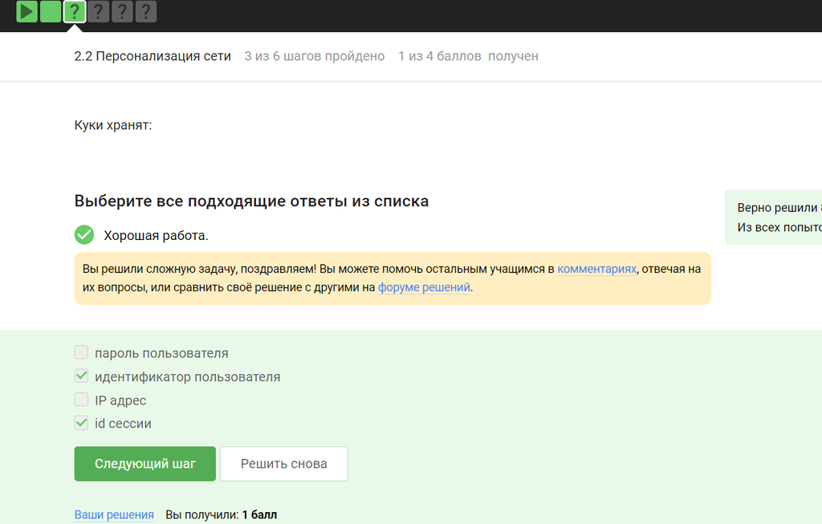

## Вопрос 2.2.2

Конечно же, куки не делают соединение более надежным

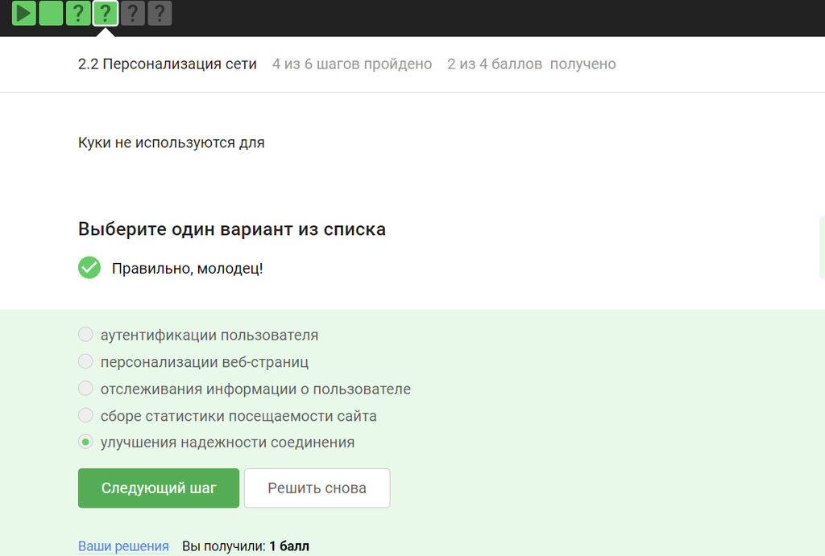

## Вопрос 2.2.3

Ответ на изображении

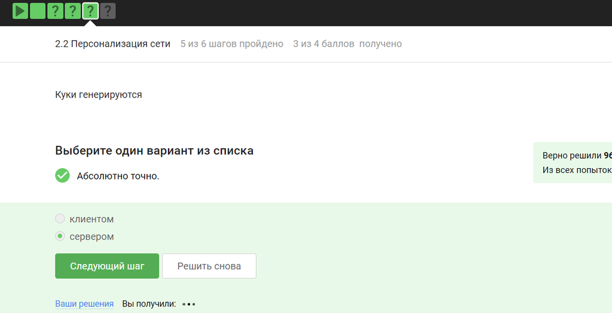

## Вопрос 2.2.4

Сессионные куки хранятся в течение сессии, то есть пока используется веб-сайт

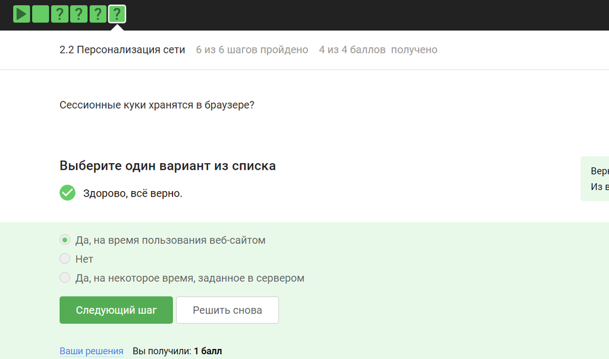

## Вопрос 2.3.1

Необходимо три узла - входной, промежуточный и выходной

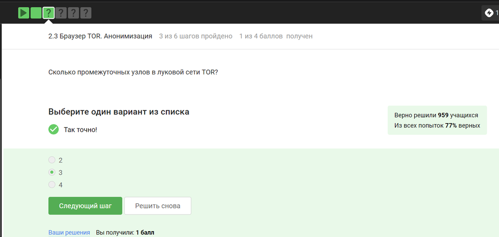

## Вопрос 2.3.2

IP-адрес не должен быть известен охранному и промежуточному узлам

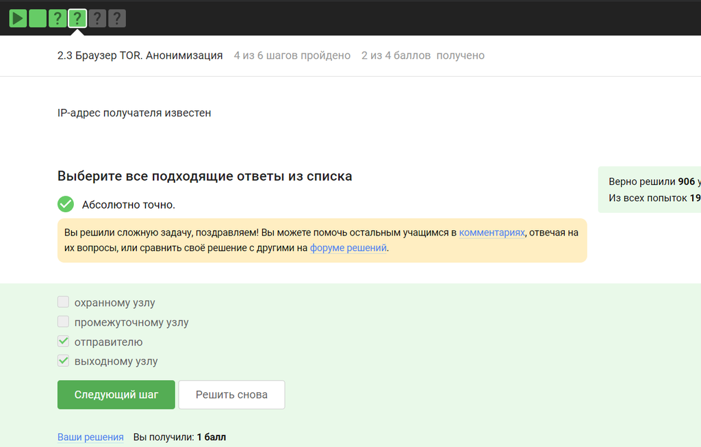

## Вопрос 2.3.3

Отправитель генерирует общий секретный ключ со узлами, через которые идет передача, то есть со всеми

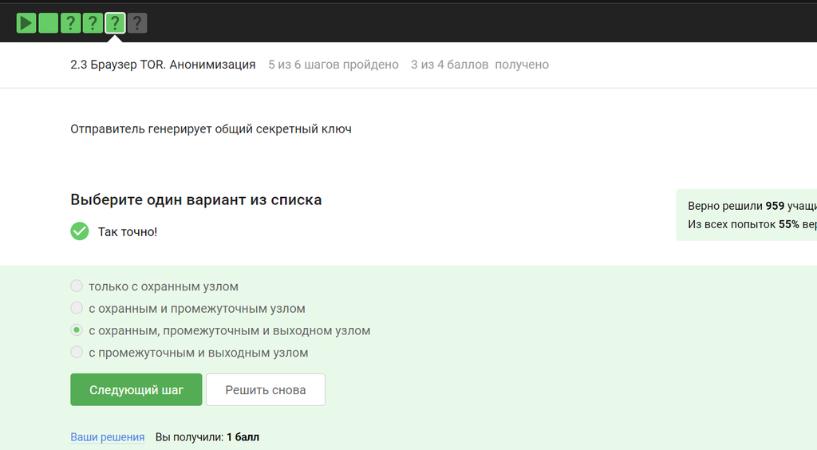

## Вопрос 2.3.4

Для получения пакетов не нужно использовать TOR. TOR — это технология, которая позволяет с некоторым успехом скрыть личность человека в интернете

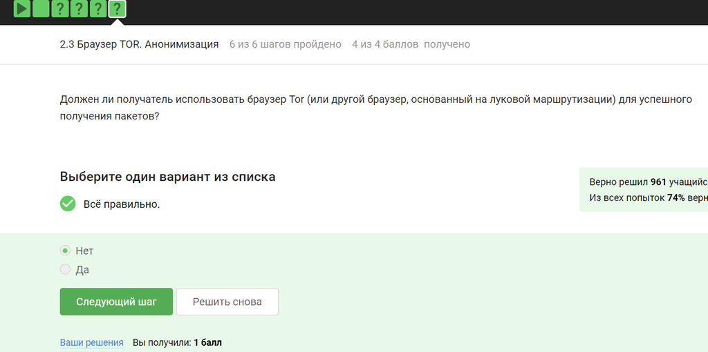

## Вопрос 2.4.1

Действительно, это определение Wi-Fi

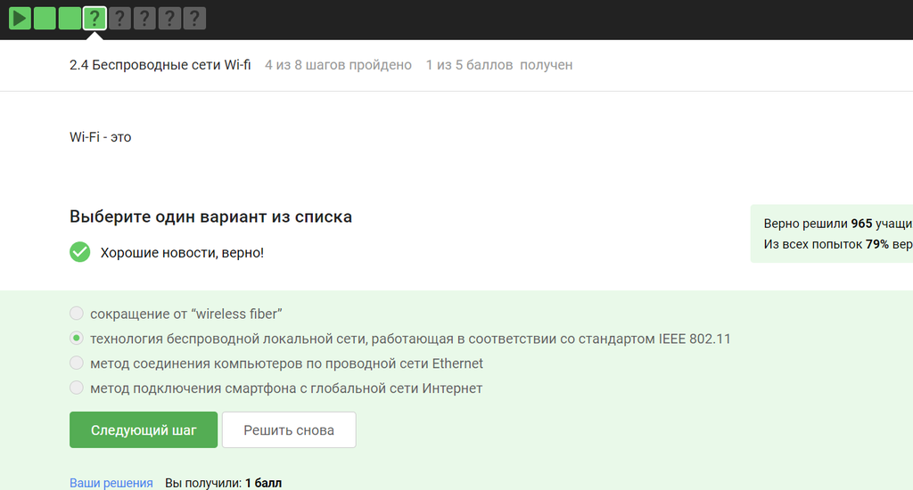

## Вопрос 2.4.2

Для целей работы в Интернете Wi-Fi обычно располагается как канальный уровень (эквивалентный физическому и канальному уровням модели OSI) ниже интернет-уровня интернет-протокола. Это означает, что узлы имеют связанный интернет-адрес, и при подходящем подключении это обеспечивает полный доступ в Интернет.

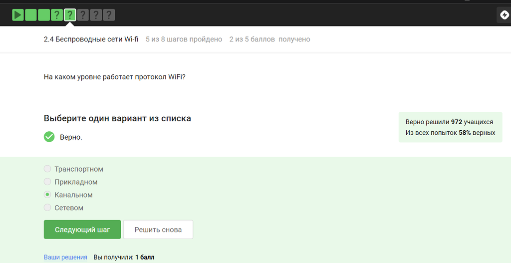

## Вопрос 2.4.3

WEP (Wired Equivalent Privacy) – устаревший и небезопасный метод проверки подлинности. Это первый и не очень удачный метод защиты. Злоумышленники без проблем получают доступ к беспроводным сетям, которые защищены с помощью WEP, был заменен остальными представленными

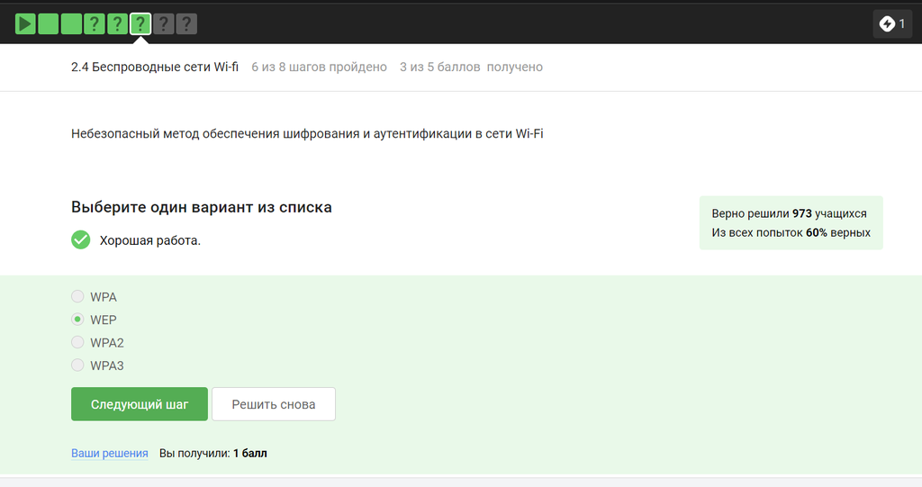

## Вопрос 2.4.4

Нужно аутентифицировать устройства и позже передаются зашифрованные данные

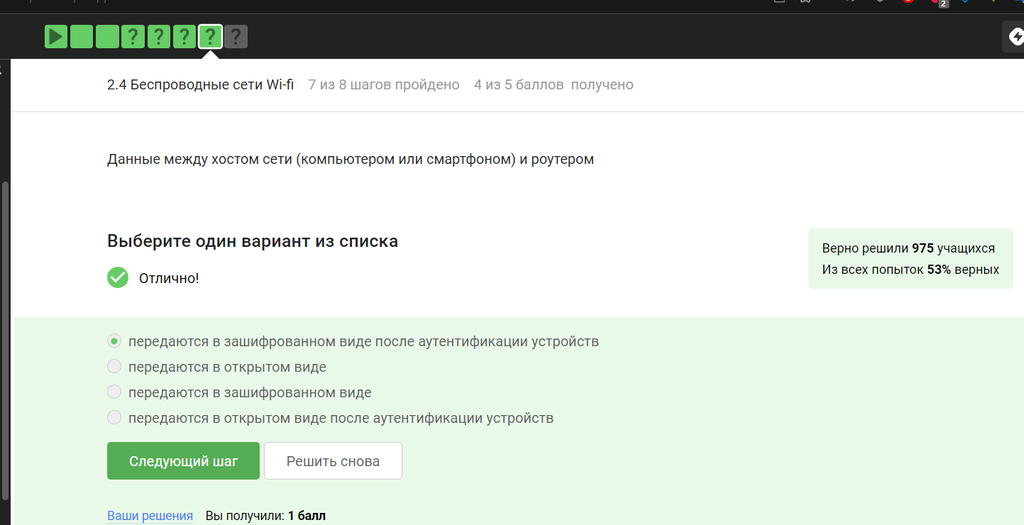

## Вопрос 2.4.5

Исходя из названия, можно понять, что WPA2 Personal для личного использования, то есть для домашней сети, enterprise - для предприятий

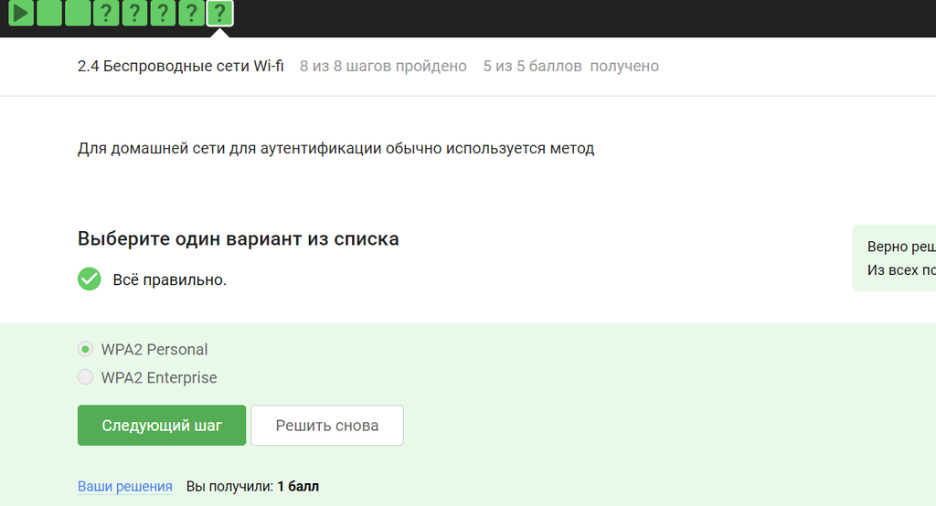

## Вывод

В ходе выполнения блока “Безопасность в сети” узнала о работе базовых сетевых протоколов, куки сетей Wi-Fi и браузера TOR.